# Linear Regression Assignment: Model Specification, Comparison, and Interpretation

- Show All Code
- Hide All Code
- View Source

Investigate overall workplace rating using several workplace attitude variables as predictors

Author

Qiu Caotao (Genesis)

## Purpose

I will use the `datasets::attitude` dataset to investigate associations between overall workplace rating (‘rating’) and three workplace attitude variables,including handling of employee complaints (‘complaints’), opportunity to learn (‘learning’), and pay increases (‘raises’).

My objectives are to:

1. Specify and estimate several plausible competing regression models.
2. Compare nested models using F-tests and changes in explained variance.
3. Evaluate overall model performance using R², adjusted R², and RMSE.
4. Examine regression diagnostics.
5. Select and interpret a preferred model.
6. Report results reproducibly using Quarto.

All numerical results in this document are generated directly from the analysis.

## 1. Load packages and prepare the data

```r
library(dplyr)
library(tidyr)
library(ggplot2)
library(broom)
library(performance)
library(gt)

dat <- attitude |>
  select(rating, complaints, learning, raises) |>
  drop_na()

n <- nrow(dat)
```

This dataset contains overall workplace rating, and several other variables summarize employee attitudes toward different aspects of the workplace, including: handling of employee complaints, opportunity to learn, and pay increases.

I use complete cases for all variables so that the candidate models are estimated using the same observations.

The final analysis includes **30 observations**.

### Research question and predictions

How are handling of employee complaints, opportunity to learn, and pay increases associated with overall workplace rating?

I expect:

- Higher/better handling of employee complaints associate with higher overall workplace rating.
- Higher/more opportunities to learn associate with higher overall workplace rating.
- Higher/more pay increases associate with higher overall workplace rating.

## 2. Explore the data

### Descriptive statistics

```r
descriptives <- dat |>
  summarise(
    across(
      c(rating, complaints, learning, raises),
      list(mean = mean, sd = sd, min = min, max = max)
    )
  ) |>
  pivot_longer(
    everything(),
    names_to = c("variable", ".value"),
    names_sep = "_"
  )

descriptives |>
  gt() |>
  fmt_number(columns = where(is.numeric), decimals = 2)
```

Descriptive statistics for continuous variables

| variable | mean | sd | min | max |
| --- | --- | --- | --- | --- |
| rating | 64.63 | 12.17 | 40.00 | 85.00 |
| complaints | 66.60 | 13.31 | 37.00 | 90.00 |
| learning | 56.37 | 11.74 | 34.00 | 75.00 |
| raises | 64.63 | 10.40 | 43.00 | 88.00 |

### Distribution of overall workplace rating

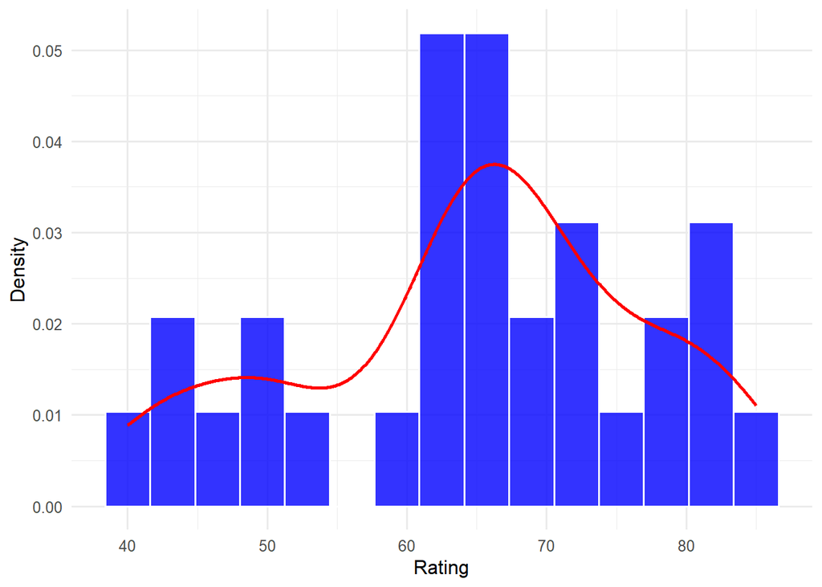

Distribution of overall workplace rating

```r
ggplot(dat, aes(x = rating)) +
  geom_histogram(
    aes(y = after_stat(density)),
    bins = 15,
    fill = "#0000FF",
    color = "white",
    alpha = 0.8
  ) +
  geom_density(
    linewidth = 0.9,
    color = "#FF0000"
  ) +
  labs(
    x = "Rating",
    y = "Density"
  ) +
  theme_minimal(base_size = 12)
```

### Relationships between predictors and overall workplace rating

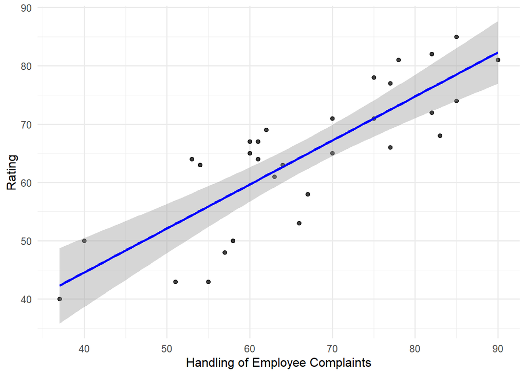

Relationship between handling of employee complaints and overall workplace rating

```r
ggplot(dat, aes(x = complaints, y = rating)) +
  geom_point(alpha = 0.75) +
  geom_smooth(
    method = "lm",
    se = TRUE,
    color = "#0000FF"
  ) +
  labs(
    x = "Handling of Employee Complaints",
    y = "Rating"
  ) +
  theme_minimal(base_size = 12)
```

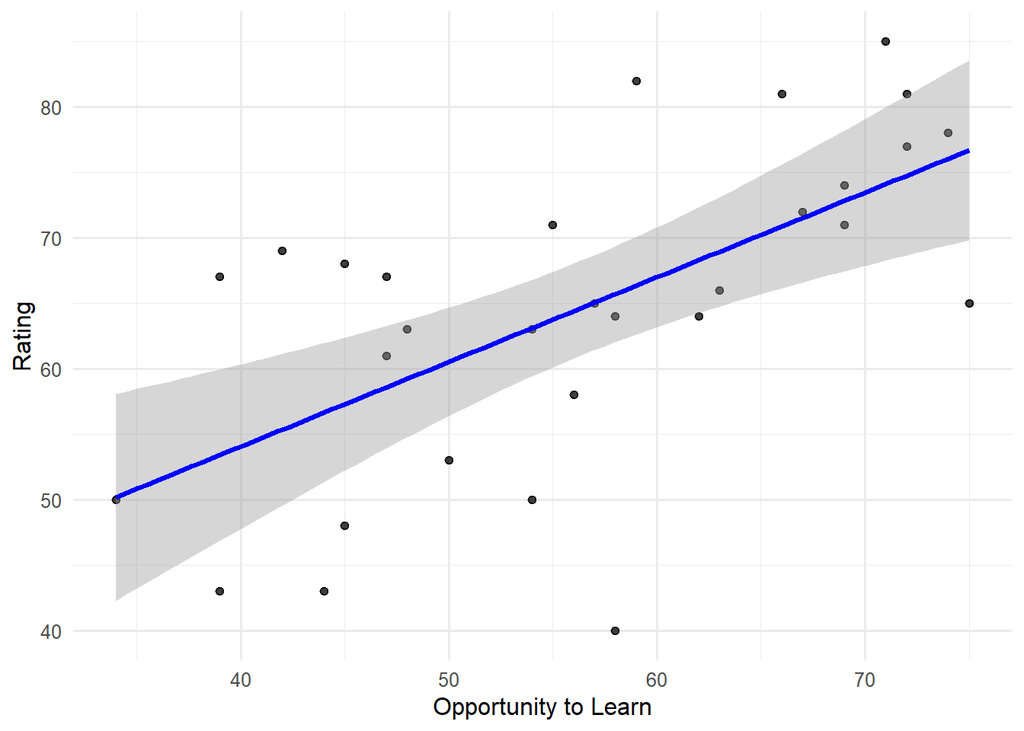

Relationship between opportunity to learn and overall workplace rating

```r
ggplot(dat, aes(x = learning, y = rating)) +
  geom_point(alpha = 0.75) +
  geom_smooth(
    method = "lm",
    se = TRUE,
    color = "#0000FF"
  ) +
  labs(
    x = "Opportunity to Learn",
    y = "Rating"
  ) +
  theme_minimal(base_size = 12)
```

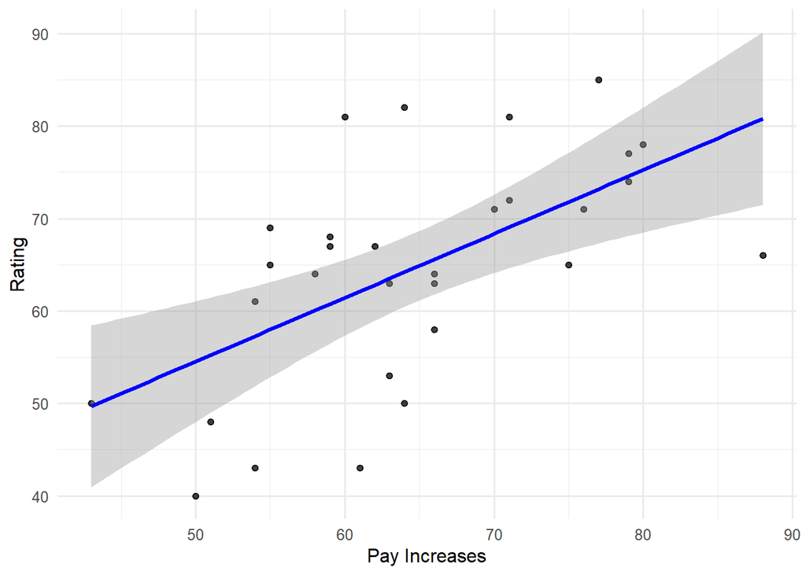

Relationship between pay increases and overall workplace rating

```r
ggplot(dat, aes(x = raises, y = rating)) +
  geom_point(alpha = 0.75) +
  geom_smooth(
    method = "lm",
    se = TRUE,
    color = "#0000FF"
  ) +
  labs(
    x = "Pay Increases",
    y = "Rating"
  ) +
  theme_minimal(base_size = 12)
```

The exploratory plots above demonstrate that the relationships between each predictor (complaints, learning, raises) and the outcome (rating) appear approximately linear, with positive correlations between all three predictors and the outcome variable.

The small amount of unusual observations in Learning and Raises (high in x but low in y and vise versa) do not appear to substantially distort the linear trends, so the exploratory results are consistent with my expectations.

The regression lines shown here are bivariate relationships rather than relationships adjusted for other predictors.

## 3. Specify and estimate competing models

I expect handling of employee complaints to be positively correlated with overall workplace rating because I hypothesize that better handling of complaints increase workplace morale that drives up overall workplace ratings.

I also expect opportunity for learning could explain additional variation beyond complaint handling because I hypothesize that more opportunity to learn also boost workplace satisfaction level that increases workplace ratings.

Finally, I expect that pay increases could explain further variation after accounting for handling complaints and opportunity to learn because I hypothesize that more often and greater pay increases improve employee satisfaction level that increases workplace ratings.

I will fit an intercept-only model and three increasingly complex substantive models.

| Model | Formula | Research rationale |
| --- | --- | --- |
| M0: Null | `rating ~ 1` | Baseline model |
| M1: Complaints | `rating ~ complaints` | Rating varies with handling of complaints |
| M2: Complaints + Learning | `rating ~ complaints + learning` | Opportunity to learn explains additional variation beyond handling of complaints |
| M3: Expanded | `rating ~ complaints + learning + raises` | Pay increases explains additional variation beyond opportunity to learn and handling of complaints |

The models are **nested**: each successive model contains all predictors from the preceding model, plus one or more additional predictors.

```r
# Intercept-only (null) model
mod0 <- lm(rating ~ 1, data = dat)

# Complaints model
mod1 <- lm(rating ~ complaints, data = dat)

# Complaints + learning model
mod2 <- lm(rating ~ complaints + learning, data = dat)

# Expanded model
mod3 <- lm(rating ~ complaints + learning + raises, data = dat)
```

### Inspecting the models

```r
summary(mod0)
summary(mod1)
summary(mod2)
summary(mod3)

confint(mod3)
```

- In M0, the intercept represents the sample mean workplace rating score.
- In M1, the complaints coefficient represents the expected difference in workplace rating associated with a 1-point difference in handling of employee complaints.
- In M2, the complaints coefficient represents this conditional association after adjusting for (holding constant) opportunity to learn, which slightly reduces the magnitude of the complaints slope because complaints and learning are positively correlated
- In M3, the complaints and learning coefficients are additionally adjusted for pay increases.

## 4. Compare the models

I will evaluate the models using two complementary approaches.

**Nested-model F-tests** determine whether the additional predictors in a larger model produce a statistically significant improvement in fit.

**Overall model performance** describes how well each model fits the observed data.

My main performance metrics are:

- **R²:** Proportion of variation explained.
- **Adjusted R²:** Explained variation adjusted for model complexity.
- **RMSE:** Root mean squared error, expressed in rating units.
- **ΔR²:** Increase in explained variation compared with the preceding model.

### 4.1. Conduct nested-model comparisons

Because my models are nested and estimated using the same observations, I can compare all four models in a single `anova()` call.

```r
tests <- anova(mod0, mod1, mod2, mod3)

tests
```

```
Analysis of Variance Table

Model 1: rating ~ 1
Model 2: rating ~ complaints
Model 3: rating ~ complaints + learning
Model 4: rating ~ complaints + learning + raises
  Res.Df    RSS Df Sum of Sq       F    Pr(>F)
1     29 4297.0
2     28 1369.4  1   2927.58 60.7256 2.884e-08 ***
3     27 1254.6  1    114.73  2.3799    0.1350
4     26 1253.5  1      1.19  0.0246    0.8765
---
Signif. codes:  0 '***' 0.001 '**' 0.01 '*' 0.05 '.' 0.1 ' ' 1
```

Each row represents a model. The F-statistic and p-value on each row after the first test whether that model improves fit relative to the preceding model.

- M1 versus M0 tests the contribution of handling of employee complaints.
- M2 versus M1 tests the additional contribution of opportunity to learn.
- M3 versus M2 tests the joint additional contribution of pay increases.

```r
tests <- tests |>
  select(Res.Df, Df, F, `Pr(>F)`) |>
  rename(
    Residual.df = Res.Df,
    Nested.Df = Df,
    Nested.F.stat = F,
    Nested.p.value = `Pr(>F)`
  )
```

### 4.2. Extract overall model performance

The `glance()` function returns a one-row data frame containing model-level statistics.

I apply it to each fitted model.

```r
glance0 <- glance(mod0)
glance1 <- glance(mod1)
glance2 <- glance(mod2)
glance3 <- glance(mod3)
```

I then combine these results using `rbind()`.

```r
mods <- c(
  "M0: Null",
  "M1: Complaints",
  "M2: Complaints + Learning",
  "M3: Complaints + Learning + Raises"
)

glances <- rbind(
  glance0,
  glance1,
  glance2,
  glance3
)
```

### 4.3. Combine nested tests and model performance

Because the rows in `glances` and `tests` represent the same models in the same order, I can combine them using `cbind()`.

```r
comparison_table <- cbind(
  Model = mods,
  glances,
  tests
)
```

Next, I calculate the change in R² between successive models using `lag()`.

I will also calculate RMSE directly from each model’s residuals.

```r
comparison_table <- comparison_table |>
  mutate(
    Delta.R2 = r.squared - lag(r.squared),

    RMSE = c(
      sqrt(mean(residuals(mod0)^2)),
      sqrt(mean(residuals(mod1)^2)),
      sqrt(mean(residuals(mod2)^2)),
      sqrt(mean(residuals(mod3)^2))
    )
  ) |>
  select(
    Model,
    r.squared,
    adj.r.squared,
    RMSE,
    Delta.R2,
    Residual.df,
    Nested.Df,
    Nested.F.stat,
    Nested.p.value
  )
```

### 4.4. Display the combined model-comparison table

```r
comparison_table |>
  gt() |>
  cols_label(
    Model = "Model",
    r.squared = "R²",
    adj.r.squared = "Adjusted R²",
    RMSE = "RMSE",
    Delta.R2 = "ΔR²",
    Residual.df = "Residual df",
    Nested.Df = "Nested df",
    Nested.F.stat = "Nested F",
    Nested.p.value = "Nested p"
  ) |>
  fmt_number(
    columns = c(
      r.squared,
      adj.r.squared,
      RMSE,
      Delta.R2,
      Nested.F.stat
    ),
    decimals = 3
  ) |>
  fmt(
    columns = Nested.p.value,
    fns = function(x) {
      ifelse(
        is.na(x),
        "—",
        ifelse(x < .001, "< .001", sprintf("%.3f", x))
      )
    }
  ) |>
  sub_missing(
    columns = c(Delta.R2, Nested.Df, Nested.F.stat),
    missing_text = "—"
  )
```

Overall model performance and incremental nested-model comparisons

| Model | R² | Adjusted R² | RMSE | ΔR² | Residual df | Nested df | Nested F | Nested p |
| --- | --- | --- | --- | --- | --- | --- | --- | --- |
| M0: Null | 0.000 | 0.000 | 11.968 | — | 29 | — | — | — |
| M1: Complaints | 0.681 | 0.670 | 6.756 | 0.681 | 28 | 1 | 60.726 | < .001 |
| M2: Complaints + Learning | 0.708 | 0.686 | 6.467 | 0.027 | 27 | 1 | 2.380 | 0.135 |
| M3: Complaints + Learning + Raises | 0.708 | 0.675 | 6.464 | 0.000 | 26 | 1 | 0.025 | 0.876 |

### Interpreting the combined table

Each row represents one fitted model.

The first set of statistics describes the **overall performance** of that model:

- R²
- Adjusted R²
- RMSE

The second set describes its **incremental improvement** relative to the preceding model:

- ΔR²
- Nested degrees of freedom
- Nested F statistic
- Nested p value

The M3 comparison tests the joint contribution of pay increases after accounting for handling scores of employee complaints and opportunity to learn.

The M0 row has no incremental comparison because it serves as the baseline.

M2 (R² = **0.708**) and M3 (R² = **0.708**) explains the largest proportion of variation in rating measured by R².

However, M2 (Adjusted R² = **0.686**) has a higher adjusted R² than both M1 (Adjusted R² = **0.67**) and M3 (Adjusted R² = **0.675**).

Adjusted R² increases slightly when learning is added in M2 but decreases when raises is added in M3.

In M1, complaints explains (**0.681**) in additional variance compare to M0 measured in ΔR².

In M2, learning explains (**0.027**) in additional variance compare to M1 measured in ΔR².

In M3, raises explains (**0**) in additional variance compare to M2 measured in ΔR².

Overall, M1 (complaints) explains the vast majority of variance. Only M1 (p **< .001**) produces statistically significant improvements in fit measured in nested F-tests, whereas adding learning in M2 (p = **0.135**) and raises in M3 (p = **0.876**) does not yield statistically significant improvement.

Similarly, M1 (RMSE = **6.756**) shows a large, substantively meaningful reduction in RMSE from M0 (RMSE = **11.968**), whereas M2 (RMSE = **6.467**) offers only a modest further reduction and M3 (RMSE = **6.464**) provides none.

### 4.5. Additional performance comparison

```r
performance_comparison <- compare_performance(
  mod0,
  mod1,
  mod2,
  mod3,
  rank = TRUE
)
```

```r
performance_comparison
plot(performance_comparison)
```

[output not shown]

These functions may include additional metrics such as AIC and BIC, which I will not focus on here.

## 5. Select a provisional model

Model selection requires considering both statistical evidence and model complexity.

In particular, I consider:

1. Whether adding predictors significantly improves model fit.
2. How much additional variation is explained.
3. Whether adjusted R² improves.
4. Whether RMSE meaningfully decreases.
5. Whether the added complexity is substantively justified.

To balance explanatory power, parsimony and substantive interpretability, I will select the model that maximizes **adjusted R²** while evaluating its trade-offs against the nested F-tests and RMSE.

```r
selected_row <- comparison_table |>
  slice_max(
    order_by = adj.r.squared,
    n = 1,
    with_ties = FALSE
  )

selected_name <- selected_row$Model

selected_model <- switch(
  selected_name,
  "M0: Null" = mod0,
  "M1: Complaints" = mod1,
  "M2: Complaints + Learning" = mod2,
  "M3: Complaints + Learning + Raises" = mod3
)
```

The provisionally selected model is **M2: Complaints + Learning**.

Its performance is:

- R² = **0.708**
- Adjusted R² = **0.686**
- RMSE = **6.47** rating points.

Although the incremental F-tests for adding learning variable in M2 is not statistically significant at the alpha = .05 level (F = **2.38**, p = **0.135**), M2 explains an additional (**2.7**)% of variance, achieves the highest adjusted R², and lowers RMSE from (**6.76**) to (**6.47**) points.

Retaining learning variable also allows me to evaluate the conditional association of complaint handling while holding the learning opportunities constant.

By contrast, M3 is clearly inferior because adding raises variable explains zero additional variance and penalized adjusted R².

## 6. Evaluate regression diagnostics

Regression diagnostics help identify potential violations of model assumptions and unusual observations.

I will now examine whether the selected model has important diagnostic problems in following parameters:

- Linearity.
- Residual normality.
- Heteroscedasticity.
- Influential observations.
- Multicollinearity.

### Standard diagnostic plots

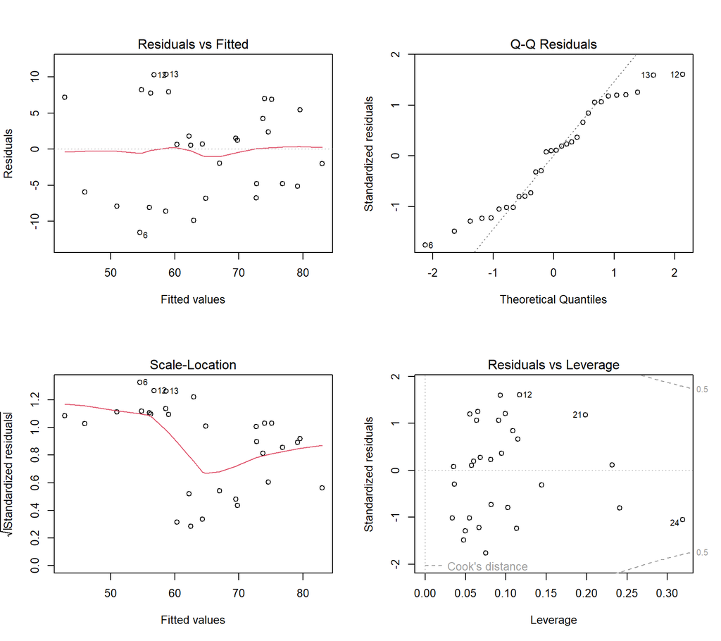

Regression diagnostic plots for the provisionally selected model

```r
op <- par(mfrow = c(2, 2))

plot(selected_model)
```

```r
par(op)
```

I consider following diagnostic plots:

**Residuals versus fitted values (Linearity)**

There is no evidence of curvature or systematic patterns in residuals vs fitted, the relationship between predictors and the outcome is adequately represented by the model.

**Normal Q–Q plot (Normality)**

The residuals are approximately normally distributed, although the lower and upper tails of the residuals deviate moderately from the reference line. Given the small sample size (n = 30), this mild tail deviation is worth knowing but not severe.

**Scale–location plot (Homoscedasticity)**

Residual variability fluctuates slightly across the middle range of fitted values, which suggests mild heteroscedasticity.

**Residuals versus leverage (Influential Observations)**

No observations fall outside Cook’s distance contours, indicating that no single observation disproportionately influences the fitted model.

**Multicollinearity**

### Additional diagnostics

I also use The `performance` package that provides a more comprehensive diagnostic interface.

```r
check_model(selected_model)
```

[output not shown]

For models with multiple predictors, I also investigate multicollinearity:

```r
check_collinearity(selected_model)
```

[output not shown]

A model with slightly better fit statistics may not be preferable if its assumptions are seriously compromised.

Based on these diagnostics, I would retain the previously chosen model (**M2: Complaints + Learning**) as my final preferred model. Because the linearity, influential observation and multicollinearity assumption checks are well satisfied, and the mild tail deviations in normality and slight heteroscedasticity are minor issues in a small sample of n = 30 departments and do not undermine my confidence in the model estimates.

## 7. Report the selected model

### 7.1. Extract regression coefficients

I use the `tidy()` function to extract coefficient-level results from a fitted model.

```r
coefficient_results <- tidy(
  selected_model,
  conf.int = TRUE,
  conf.level = 0.95
)
```

The resulting data frame contains:

- Coefficient estimates.
- Standard errors.
- Test statistics.
- p-values.
- Confidence interval limits.

### 7.2. Create a regression coefficient table

```r
coefficient_results |>
  select(
    term,
    estimate,
    std.error,
    conf.low,
    conf.high,
    p.value
  ) |>
  gt() |>
  cols_label(
    term = "Predictor",
    estimate = "Estimate",
    std.error = "SE",
    conf.low = "95% CI lower",
    conf.high = "95% CI upper",
    p.value = "p"
  ) |>
  fmt_number(
    columns = c(
      estimate,
      std.error,
      conf.low,
      conf.high
    ),
    decimals = 3
  ) |>
  fmt(
    columns = p.value,
    fns = function(x) {
      ifelse(
        x < .001,
        "< .001",
        sprintf("%.3f", x)
      )
    }
  )
```

Unstandardized regression coefficients for the selected model

| Predictor | Estimate | SE | 95% CI lower | 95% CI upper | p |
| --- | --- | --- | --- | --- | --- |
| (Intercept) | 9.871 | 7.061 | −4.618 | 24.359 | 0.174 |
| complaints | 0.644 | 0.118 | 0.400 | 0.887 | < .001 |
| learning | 0.211 | 0.134 | −0.065 | 0.487 | 0.128 |

### 7.3. Report overall model performance

```r
selected_row |>
  select(
    Model,
    r.squared,
    adj.r.squared,
    RMSE
  ) |>
  gt() |>
  cols_label(
    Model = "Model",
    r.squared = "R²",
    adj.r.squared = "Adjusted R²",
    RMSE = "RMSE"
  ) |>
  fmt_number(
    columns = where(is.numeric),
    decimals = 3
  )
```

Overall performance of the selected model

| Model | R² | Adjusted R² | RMSE |
| --- | --- | --- | --- |
| M2: Complaints + Learning | 0.708 | 0.686 | 6.467 |

## 8. Interpret the results

### Overall model performance

The selected model, **M2: Complaints + Learning**, explains approximately **70.8%** of the variation in overall workplace rating within this sample (R² = **0.708**).

Its adjusted R² is **0.686**, and its in-sample RMSE is **6.47 rating points**.

The RMSE describes the typical magnitude of the model’s fitted residuals on a root-mean-square scale.

It should not be interpreted as an estimate of out-of-sample predictive accuracy.

### Interpreting complaints

Holding the other predictors constant, a 1-point increase in handling of employee complaints is associated with a significant **0.64-point** increase in predicted workplace rating, 95% CI [0.4, 0.89].

### Interpreting learning

Holding handling of employee complaints constant, a 1-point increase in opportunity to learn is associated with a **0.2112-point** increase in predicted workplace rating, 95% CI [-0.065, 0.487], however, this conditional association is not statistically significant at the alpha = .05 level because the confidence interval includes zero.

### Substantive conclusions

Substantively, these results indicate that handling of employee complaints is by far the most important predictor of overall workplace rating among the variables examined. Alone, complaint handling accounts for **68.1%** of the variance in workplace ratings, and its strong positive association remains robust even after adjusting for learning opportunities and pay increases.

Opportunities to learn play a secondary, modest role, accounting for an addition **2.7%** of variance that improves adjusted R² slightly but does not reach statistical significance once complaint handling is held constant.

Finally, pay increases contribute virtually no unique explanatory power (ΔR² < .001) beyond complaint handling and learning opportunities, showing that its positive bivariate relationship with workplace ratings is largely redundant with how well departments handle complaints and provide learning opportunities.

However, several limitations should be recognized:

- The observations describe departments (n = 30) rather than individual employees.
- The data are observational, so regression coefficients represent conditional associations rather than causal effects.
- The small sample size (n = 30) limits statistical power to detect smaller conditional associations, such as the unique contribution of opportunities to learn.
- Model diagnostics indicate mild tail deviations from normality and slight heteroscedasticity.
- In-sample model performance does not establish out-of-sample predictive accuracy.